# Aplicacion de vacunas COVID19 en Argentina - NOMIVAC: 2020-2023

Lautaro Felipe Skubaletzky

2023-06-07

# 1 Introducción al uso de datos de la base NOMIVAC.

## 1.1 Importar datos -> Muestra

Se importan los datos en un dataframe de nombre `data`. Se limita la cantidad máxima de filas a importar en la variable `mi_muestra_registros`.

```r
rm(list = ls())
set.seed(8)

# Defino mi sample registros
mi_muestra_registros <- 100000

# Data filepath
file_path <- "datos/datos_nomivac_covid19.csv"

#data <- read_csv(file_path, n_max = 10000, show_col_types = FALSE, col_select = c(id_persona_dw, fecha_aplicacion)) ## queria hacer un join luego de obtener un recorte por ultima fecha y sample.

# Import / read data
data_registro <- read_csv(file_path, n_max = mi_muestra_registros, show_col_types = FALSE)
obs_filas <- nrow(data_registro)
print(paste("Reporte parcial: Se cargan:", obs_filas, "sobservaciones."))
```

```
## [1] "Reporte parcial: Se cargan: 100000 sobservaciones."
```

```r
#Reporte parcial: Se cargan `r nrow(data)` observaciones.

rm(obs_filas, file_path, mi_muestra_registros)
```

### 1.1.1 Muestra -> Sample

Se realiza un **sample** de la muestra de datos importada al environment para reducir el tiempo computacional del procesamiento del informe. `mi_sample_registros`

```r
# Defino mi sample registros
mi_sample_registros <- 10000

# Mi sample persona es la muestra de personas que se extrae. Esto va implicar que estas son las personas que tendran inclusion en el analisis y que son quienes daran valores a las tablas, graficos, etc. Adicionalmente estas personas y sus registros de vacunacion seran incluidos en los analisis temporales de la ultima parte.
data_registro <- data_registro[sample(1:nrow(data_registro), mi_sample_registros, replace = TRUE), 1:18]
rm(mi_sample_registros)
```

#### 1.1.1.1 Muestra -> Sample -> Registros únicos por cada persona (max(fecha))

Sobre la muestra aleatoria obtenida se seleccionan los **últimos registros** de vacunacion de cada persona. Se obtiene así una *“foto”* estática de esas personas en el momento mas actualizado. `data_persona`

```r
data_persona <- data_registro %>%
  group_by(id_persona_dw) %>%
  filter(fecha_aplicacion == max(fecha_aplicacion))

#data_persona <- data_persona[,]
```

## 1.2 Registros múltiples

A continuacion se realizó un join entre la `data_persona` y `data_registro`, y como resultado se obtiene un mensaje de **many to many**. Se esperaba que fuera una base de **one to many** al obtener para la base personas el último registro de vacunación dado por la `fecha_aplicacion`. El resultado motivó a indagar más alcanzando la conclusión que la base tiene algunos errores o duplicados que se quitan a continuación. Abajo una posible solución de quitarlos de análisis.

```r
# se descubrio que varias personas tiene multiples registros en la misma fecha. Habria que inspeccionar mas detalles sobre esas personas y esas fechas de aplicacion en las que coinciden varios registros.

# data_persona = # 9804 total de registros "personas" -> pero no porque hay registros multiples dentro de la misma fecha: `max(fecha_aplicacion)`.

# data_persona: # 9296 entre unicos y multiples
data_persona %>%
  group_by(id_persona_dw) %>%
  summarise(n = n()) %>%
  arrange(desc(n))
```

```
## # A tibble: 9,296 × 2
##    id_persona_dw     n
##            <dbl> <int>
##  1   12007765465     3
##  2   12014618961     3
##  3   14011198181     3
##  4   14013984837     3
##  5   14016590235     3
##  6   14020309567     3
##  7   14044211043     3
##  8   14045236173     3
##  9   14045237995     3
## 10   14048575753     3
## # ℹ 9,286 more rows
```

```r
# personas con multiples registros en su `max(fecha_aplicacion)` -> a esta altura seria prudente cruzar toda la base no solamente con la fecha maxima de aplicacion sino toda group_by(id_persona_dw, fecha_aplicacion)

# data_persona_multiple: 491 registros de personas con multiples.
data_persona_multiple <- data_persona %>%
  group_by(id_persona_dw) %>%
  summarise(n = n()) %>%
  arrange(desc(n)) %>%
  filter(n != 1) %>%
  select(id_persona_dw)

# data_persona_unica: 8805 registros de personas con unicas.
data_persona_unica <- data_persona %>%
  group_by(id_persona_dw) %>%
  summarise(n = n()) %>%
  arrange(desc(n)) %>%
  filter(n == 1) %>%
  select(id_persona_dw)
```

## 1.3 Join de `data_persona_unica` & `data_registro`

Union de `data_persona` con `data_registro` de esas personas y solamente de esas personas.

```r
# Primera base de datos con personas (sin repetirse)
data_persona_unica %>%
  group_by(id_persona_dw) %>%
  summarise(n = n()) %>%
  arrange(desc(n)) ## chequeado que son `id_persona_dw` unicas
```

```
## # A tibble: 8,805 × 2
##    id_persona_dw     n
##            <dbl> <int>
##  1       -244535     1
##  2       -230893     1
##  3       -175169     1
##  4       -169641     1
##  5       -130971     1
##  6       -101753     1
##  7        -83599     1
##  8        -37803     1
##  9        -37763     1
## 10        -32761     1
## # ℹ 8,795 more rows
```

```r
# Segunda base de datos con todos los registros
# data_registro

# Realizar el join uno a muchos
data_join <- inner_join(data_persona_unica, data_registro, by = "id_persona_dw")


# compruebo que los valores de la lista de `id_persona` de `data_persona_multiple` no se encuentren comprendidos en los valores de la lista de `id_persona` de `data_join`. La que de ahora en adelante será nuestra base de registros multiples de aquella otra base de personas unicas.
vector_logico <- data_persona_multiple$id_persona_dw %in% data_join$id_persona_dw
# Comprobar si hay al menos un TRUE
existe_true <- any(vector_logico)
if (existe_true) {
  print("El vector contiene al menos un TRUE, entonces la lista de registros unicos aun tiene registros multiples.")
} else {
  print("El vector no contiene ningún TRUE, entonces la lista de registros unicos es cierta.")
}
```

```
## [1] "El vector no contiene ningún TRUE, entonces la lista de registros unicos es cierta."
```

```r
# Genero la base personas unicas final:
data_per <- data_join %>%
  group_by(id_persona_dw) %>%
  filter(fecha_aplicacion == max(fecha_aplicacion))

# Genero la base registros de personas unicas final
assign("data_reg", data_join, envir = .GlobalEnv)

data_reg %>%
  group_by(id_persona_dw) %>%
  summarise(n = n()) %>%
  arrange(desc(n))
```

```
## # A tibble: 8,805 × 2
##    id_persona_dw     n
##            <dbl> <int>
##  1       3225839     3
##  2   14031984467     3
##  3   14060629505     3
##  4   14092257341     3
##  5   14095831031     3
##  6   14124414899     3
##  7   14128253987     3
##  8   14132839093     3
##  9        190199     2
## 10        222075     2
## # ℹ 8,795 more rows
```

```r
data_per %>%
  group_by(id_persona_dw) %>%
  summarise(n = n()) %>%
  arrange(desc(n))
```

```
## # A tibble: 8,805 × 2
##    id_persona_dw     n
##            <dbl> <int>
##  1       -244535     1
##  2       -230893     1
##  3       -175169     1
##  4       -169641     1
##  5       -130971     1
##  6       -101753     1
##  7        -83599     1
##  8        -37803     1
##  9        -37763     1
## 10        -32761     1
## # ℹ 8,795 more rows
```

```r
# elimino los demas df creados para comprobacion y busqueda de registros unicos y multiples.
rm(data_join, data_registro, data_persona, data_persona_multiple, data_persona_unica, vector_logico, existe_true)
```

Me gustaría importar los datos de todas las personas, solamente variable `id_persona_dw`, para no sobrecargar de datos la memoria de la pc. Luego armar una base de registros `id_persona_dw` unicos de 5000 observaciones y luego alli hacer un join para todas esas personas ID traer toda la informacion de sus vacunaciones. La dificultad de realizar este paso es que no se permite hacer joins_ con bases no cargadas al environment de RSTUDIO.

```r
# file_path <- "datos/datos_nomivac_covid19.csv"
# base_completa <- read_csv(file_path)[1:10,18:18]
# base_completa <- read_csv(file_path, col_select = c(id_persona_dw), n_max = 10, show_col_types = FALSE)
# left_join(data, "datos/datos_nomivac_covid19.csv", by = id_persona_dw)
```

## 1.4 Exploración de los datos

Esta sección contiene una breve descripcion de los datos cargados.

- Estructura de los datos
  - Intervalo de fechas del registro
  - Rango y magnitud de la base
- Descripcion de variables de interés
  - Dominio de las variables (valores únicos)
  - Normalizacion de valores

### 1.4.1 Estructura de los datos

#### 1.4.1.1 Intervalo de fechas del registro (primero y último del recorte)

Quiero saber entre que fechas dispongo de informacion de registros de vacunación.

```r
fecha_0 <- summarise(data_reg, min(fecha_aplicacion))
fecha_T <- summarise(data_reg, max(fecha_aplicacion))

#fecha_0_st <- paste0(year(fecha_0),"-" , month(fecha_0),"-", day(fecha_0))
#fecha_T_st <- paste0(year(fecha_T),"-" , month(fecha_T),"-", day(fecha_T))

#fecha_0_formateada <- format(fecha_0, "%Y-%m-%d")
#fecha_T_formateada <- format(fecha_T, "%Y-%m-%d")

print(paste0("la primer fecha disponible es del ", fecha_0, " y la ultima fecha de actualizacion es del ", fecha_T))
```

```
## [1] "la primer fecha disponible es del 18703 y la ultima fecha de actualizacion es del 19494"
```

```r
#La primer observacion se registró el **`r fecha_0`** y la última se registró el **`r fecha_T`**.
rm(fecha_0, fecha_T)
```

#### 1.4.1.2 Rango y magnitud de la base (cantidad de observaciones y variables)

Se presentan las dimensiones de la base que sirve de registros.

```r
obs_filas <- nrow(data_reg) # cantidad de observaciones (filas)
obs_cols <- ncol(data_reg) # cantidad de variables (columnas)
obs_valores = obs_filas * obs_cols # cantidad de datos (celdas)
dim(data_reg)
```

```
## [1] 8991   18
```

```r
print(paste0("Los datos se estructuran en : ", obs_filas, " observaciones (filas) y ", obs_cols, " variables (columnas). Tenemos un total de ", obs_valores, " valores o celdas con datos."))
```

```
## [1] "Los datos se estructuran en : 8991 observaciones (filas) y 18 variables (columnas). Tenemos un total de 161838 valores o celdas con datos."
```

```r
#Los datos se estructuran en **`r obs_filas`** observaciones (filas) y **`r obs_cols`** variables (columnas). Tenemos un total de **`r obs_valores`** valores o celdas con datos.

rm(obs_filas, obs_cols, obs_valores)
```

### 1.4.2 Descripción de variables de interés

Presentacion de las variables, a título informativo estos son los nombres. A continuación se seleccionan algunas variables para brindar mayores detalles de las mismas.

```r
colnames(data_per)
```

```
##  [1] "id_persona_dw"              "sexo"
##  [3] "grupo_etario"               "jurisdiccion_residencia"
##  [5] "jurisdiccion_residencia_id" "depto_residencia"
##  [7] "depto_residencia_id"        "jurisdiccion_aplicacion"
##  [9] "jurisdiccion_aplicacion_id" "depto_aplicacion"
## [11] "depto_aplicacion_id"        "fecha_aplicacion"
## [13] "vacuna"                     "cod_dosis_generica"
## [15] "nombre_dosis_generica"      "condicion_aplicacion"
## [17] "orden_dosis"                "lote_vacuna"
```

Estas son todas las variables disponibles.

#### 1.4.2.1 Dominio de las variables (valores únicos)

Se presentan a continuación los valores posibles que registran algunas de las variables, algo a lo que también haremos referencia como su dominio.

```r
varlist <- c("sexo","grupo_etario","condicion_aplicacion","vacuna", "nombre_dosis_generica", "orden_dosis")
for (vardin in varlist){
  var_output <- data_reg[[vardin]]
  print(levels(factor(var_output)))
  #distinct(data, var_output)
}
```

```
## [1] "F"    "M"    "S.I."
##  [1] "<12"   "12-17" "18-29" "30-39" "40-49" "50-59" "60-69" "70-79" "80-89"
## [10] "90-99"
##  [1] "12 a 17 años CON Factores de Riesgo" "12 a 17 años SIN Factores de Riesgo"
##  [3] "18 a 39 años SIN Factores de Riesgo" "18 a 59 años CON Factores de Riesgo"
##  [5] "3 a 11 años CON Factores de Riesgo"  "3 a 11 años SIN Factores de Riesgo"
##  [7] "40 a 49 años SIN Factores de Riesgo" "50 a 59 años SIN Factores de Riesgo"
##  [9] "60 o más años"                       "CON Factores de Riesgo"
## [11] "Embarazo"                            "Estratégico"
## [13] "Otros"                               "Salud"
## [15] "SIN Factores de Riesgo"              "Viaje"
##  [1] "AstraZeneca"               "Cansino"
##  [3] "Moderna 010 mg mL"         "Moderna ARNm 020 mg mL"
##  [5] "Moderna Bivariante BA 4 5" "Pfizer"
##  [7] "Pfizer Bivariante BA 4 5"  "Pfizer Pediátrica"
##  [9] "Sinopharm"                 "Sputnik"
## [11] "Sputnik Light"
## [1] "1ra"       "2da"       "Adicional" "Refuerzo"  "Unica"
## [1] "1" "2" "3" "4" "5" "6" "7"
```

```r
#summary(data) # comento summary porque al no tratarse de una base muy numerica no me sirve de mucho este resumen.

#rm(fecha_0, fecha_T, obs_cols, obs_filas, obs_valores, file_path)
rm(var_output, varlist, vardin)
```

Breve descripción del tipo de datos disponibles en NOMIVAC. La gran mayoría son character, excepcion de fecha y orden dosis, así como variables id_codigos asociadas a otras descripcion_codigos.

#### 1.4.2.2 Adecuación de valores (edición, agrupación y homogeneización)

En el siguiente archivo `scripts/normalizacion-variables-valores.R` se renombran variables, se remplazan valores de variables y se agrupan valores.

```r
source("scripts/normalizacion-variables-valores.R", local = TRUE, echo = TRUE)
```

```
##
## > max(data_reg$fecha_aplicacion)
## [1] "2023-05-17"
##
## > data_reg <- data_reg %>% rename(id_persona = id_persona_dw)
##
## > levels(factor(data_reg$sexo))
## [1] "F"    "M"    "S.I."
##
## > data_reg <- data_reg %>% mutate(sexo = ifelse(sexo ==
## +     "X", "S.I.", sexo))
##
## > levels(factor(data_reg$sexo))
## [1] "F"    "M"    "S.I."
##
## > data_reg <- data_reg %>% mutate(grupo_etario = case_when(grupo_etario ==
## +     "<12" ~ "000-012", grupo_etario == "12-17" ~ "012-017", grupo_etario .... [TRUNCATED]
##
## > data_reg <- data_reg %>% mutate(condicion_aplicacion = ifelse(condicion_aplicacion ==
## +     "60 o más años", "Adulto mayor", condicion_aplicacion))
##
## > data_reg <- data_reg %>% mutate(condicion_aplicacion = ifelse(stringr::str_detect(condicion_aplicacion,
## +     "años"), stringr::str_extract(condici .... [TRUNCATED]
##
## > data_reg <- data_reg %>% mutate(condicion_aplicacion = case_when(condicion_aplicacion ==
## +     "Adulto mayor" ~ "Adulto mayor", condicion_aplicacio .... [TRUNCATED]
##
## > max(data_per$fecha_aplicacion)
## [1] "2023-05-17"
##
## > data_per <- data_per %>% rename(id_persona = id_persona_dw)
##
## > levels(factor(data_per$sexo))
## [1] "F"    "M"    "S.I."
##
## > data_per <- data_per %>% mutate(sexo = ifelse(sexo ==
## +     "X", "S.I.", sexo))
##
## > levels(factor(data_per$sexo))
## [1] "F"    "M"    "S.I."
##
## > data_per <- data_per %>% mutate(grupo_etario = case_when(grupo_etario ==
## +     "<12" ~ "000-012", grupo_etario == "12-17" ~ "012-017", grupo_etario .... [TRUNCATED]
##
## > data_per <- data_per %>% mutate(condicion_aplicacion = ifelse(condicion_aplicacion ==
## +     "60 o más años", "Adulto mayor", condicion_aplicacion))
##
## > data_per <- data_per %>% mutate(condicion_aplicacion = ifelse(stringr::str_detect(condicion_aplicacion,
## +     "años"), stringr::str_extract(condici .... [TRUNCATED]
##
## > data_per <- data_per %>% mutate(condicion_aplicacion = case_when(condicion_aplicacion ==
## +     "Adulto mayor" ~ "Adulto mayor", condicion_aplicacio .... [TRUNCATED]
```

## 1.5 Generación de tablas y gráficos exploratorios de variables de interés

Esta sección contiene visualizaciones tabulares y gráficas estandarizadas y **estáticas** para variables de interés.

Todos los resultados que se presentan en esta seccion hacen referencia a una *foto* en el tiempo.

Es decir, las tablas y gráficos corresponden a un estado de situación en un momento determinado.

Mas adelante, en la próxima sección, se realizan análisis **dinámicos** de la evolución temporal de los datos y estadísticas afínes.

- Tablas estadísticas
  - Agrupamiento de individuos `id_persona`
  - Filtrado del último registro del individuo por fecha `fecha_aplicacion`
  - Agrupamiento por variable de interés `vardin`
  - Valores mínimos, medios y máximos de `varstat`
  - Población (n_abs): cantidad de miembros que componen el grupo (`vardin`)
  - Cantidad de registros disponibles acumulados por grupo (mean_i * N_i)
  - Población relativa (n_rel): participación del grupo sobre el total de observaciones.
- Gráficos
  - Barras
  - Líneas
  - Puntos
  - Boxplots

### 1.5.1 Loop estadísticos descriptivos de variables de interes

Obtengo algunos df sobre las cantidades y participación de la población objetivo de la vacunación desde diferentes perspectivas como son el `sexo`, `grupo_etario`, `condicion_aplicacion` y otras. Las observaciones anteriores de personas son filtradas por la variable `fecha_aplicacion` para conservar en análisis unicamente un registro, el mas actualizado por sujeto.

```r
# Seleccion de variables para armado de tablas de estadisticos descriptivos:
varlist <- c("sexo", "grupo_etario", "condicion_aplicacion", "vacuna", "nombre_dosis_generica", "lote_vacuna", "jurisdiccion_aplicacion", "jurisdiccion_residencia", "depto_aplicacion", "depto_residencia")

source("scripts/loop_estadisticos_descriptivos.R")
```

```
## [1] "."
## [1] "."
## [1] "sexo"
## [1] "La población que mas rebició vacunas en valor absoluto es: F"
## [1] "La población que mas rebició vacunas en valor relativo es: F"
## [1] "."
## [1] "."
## [1] "grupo_etario"
## [1] "La población que mas rebició vacunas en valor absoluto es: 040-049"
## [1] "La población que mas rebició vacunas en valor relativo es: 050-059"
## [1] "."
## [1] "."
## [1] "condicion_aplicacion"
## [1] "La población que mas rebició vacunas en valor absoluto es: Factores Riesgo OFF"
## [1] "La población que mas rebició vacunas en valor relativo es: Adulto mayor"
```

[output cut: 35 more lines]

```r
#ls_genvar_estdesc
```

Se realizó un loop para obtener estadisticas de cada agrupamiento segun la cantidad de dosis. Como se puede observar la suma de la variable `total_dosis` excede por bastante la cantidad de registros importados, esto es así, ya que no se importó toda la base, y los registros obtenidos ya tienen historial de vacunaciones anteriores.

```r
#varias formas de jugar con listas:
ls_genvar_texto[["sexo"]]["sexo"] ## abs
```

```
##   sexo
## 1    F
```

```r
ls_genvar_texto[["sexo"]]["sexo.1"] ## rel
```

```
##   sexo.1
## 1      F
```

```r
ls_genvar_estdesc[["sexo"]]
```

```
## # A tibble: 3 × 7
##   sexo  min_dosis mean_dosis max_dosis total_dosis poblacion participacion
##   <chr>     <dbl>      <dbl>     <dbl>       <dbl>     <int>         <dbl>
## 1 F             1       2.96         7       13952      4711        53.5
## 2 M             1       2.93         7       11945      4075        46.3
## 3 S.I.          1       2.53         4          48        19         0.216
```

```r
ls_genvar_estdesc[["sexo"]]$mean_dosis[2]
```

```
## [1] 2.931288
```

```r
max(ls_genvar_estdesc[["sexo"]]["mean_dosis"])
```

```
## [1] 2.961579
```

Para copiar y pegar debajo de var_obtener_estadisticos:

```r
#Esta base con fecha de corte hasta `r fecha_i` y agrupación por `r vardin`, la población `r mas_abs` recibió `r varstat` mas vacunas en valor absoluto y `r mas_rel` en promedio.
```

```r
print("la funcion de graficar no funciona")
```

```
## [1] "la funcion de graficar no funciona"
```

```r
print("grafico_estandar(ls_genvar_estdesc$condicion_aplicacion, condicion_aplicacion, total_dosis)")
```

```
## [1] "grafico_estandar(ls_genvar_estdesc$condicion_aplicacion, condicion_aplicacion, total_dosis)"
```

### 1.5.2 Variable `sexo`

```r
#Sexo
ls_genvar_estdesc$sexo
```

```
## # A tibble: 3 × 7
##   sexo  min_dosis mean_dosis max_dosis total_dosis poblacion participacion
##   <chr>     <dbl>      <dbl>     <dbl>       <dbl>     <int>         <dbl>
## 1 F             1       2.96         7       13952      4711        53.5
## 2 M             1       2.93         7       11945      4075        46.3
## 3 S.I.          1       2.53         4          48        19         0.216
```

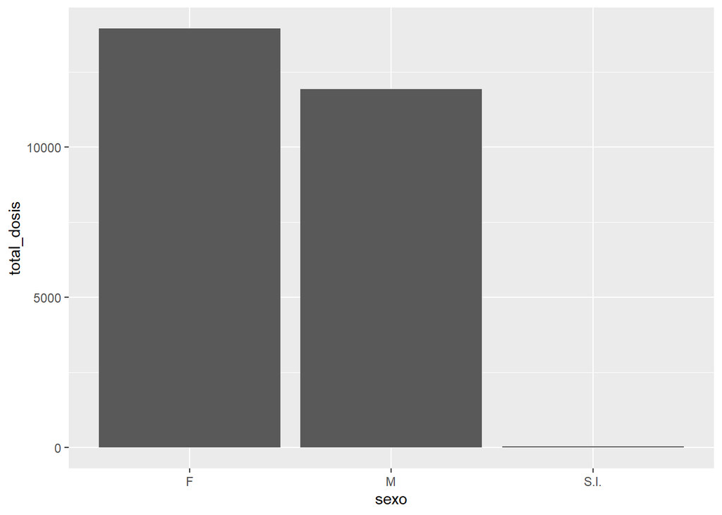

```r
ls_genvar_estdesc$sexo %>%
  ggplot(mapping = aes(sexo, total_dosis)) +
  geom_col()
```

```r
ggsave(paste0("png/grafico_estandar_","sexo", "_","total_dosis", ".png"))
```

### 1.5.3 Variable `grupo_etario`

```r
ls_genvar_estdesc$grupo_etario
```

```
## # A tibble: 10 × 7
##    grupo_etario min_dosis mean_dosis max_dosis total_dosis poblacion
##    <chr>            <dbl>      <dbl>     <dbl>       <dbl>     <int>
##  1 000-012              1       1.93         5        1797       930
##  2 012-017              1       2.58         5        2148       831
##  3 018-029              1       2.83         7        3870      1367
##  4 030-039              1       3.01         6        3787      1259
##  5 040-049              1       3.11         7        4178      1343
##  6 050-059              1       3.34         7        3976      1189
##  7 060-069              1       3.31         7        3405      1030
##  8 070-079              1       3.24         7        2017       623
##  9 080-089              1       3.32         7         665       200
## 10 090-099              1       3.09         4         102        33
## # ℹ 1 more variable: participacion <dbl>
```

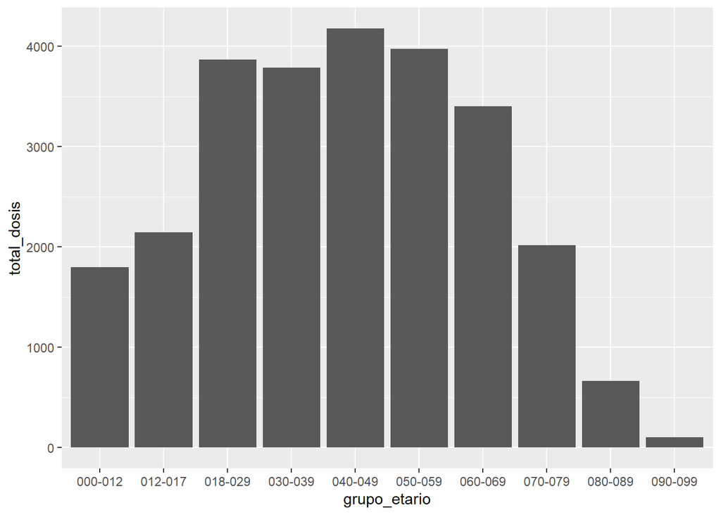

```r
ls_genvar_estdesc$grupo_etario %>%
  ggplot(mapping = aes(grupo_etario, total_dosis)) +
  geom_col()
```

```r
ggsave(paste0("png/grafico_estandar_","grupo_etario", "_","total_dosis", ".png"))
```

### 1.5.4 Variable `condicion_aplicacion`

```r
ls_genvar_estdesc$condicion_aplicacion
```

```
## # A tibble: 8 × 7
##   condicion_aplicacion min_dosis mean_dosis max_dosis total_dosis poblacion
##   <chr>                    <dbl>      <dbl>     <dbl>       <dbl>     <int>
## 1 Adulto mayor                 1       3.78         7        2206       583
## 2 Embarazo                     1       2.5          4          25        10
## 3 Estratégico                  1       3.01         6         575       191
## 4 Factores Riesgo OFF          1       2.69         7       15179      5645
## 5 Factores Riesgo ON           1       3.39         7        6939      2046
## 6 Otros                        1       3.17         5         371       117
## 7 Salud                        1       3.08         4         646       210
## 8 Viaje                        1       1.33         2           4         3
## # ℹ 1 more variable: participacion <dbl>
```

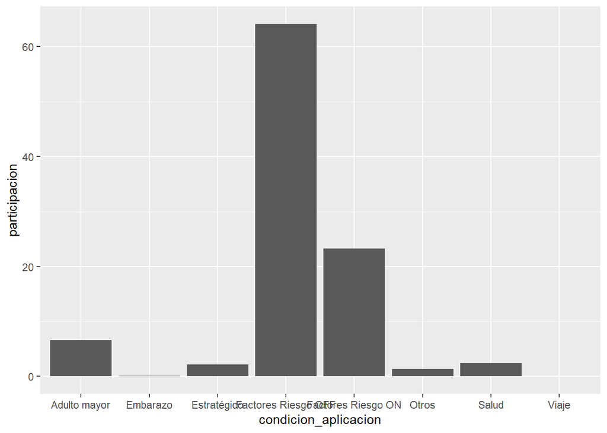

```r
ls_genvar_estdesc$condicion_aplicacion %>%
  ggplot(mapping = aes(condicion_aplicacion, participacion)) +
  geom_col()
```

```r
ggsave(paste0("png/grafico_estandar_","condicion_aplicacion", "_","total_dosis", ".png"))
```

### 1.5.5 Variable `jurisdiccion_aplicacion`

```r
ls_genvar_estdesc$jurisdiccion_aplicacion
```

```
## # A tibble: 24 × 7
##    jurisdiccion_aplicacion min_dosis mean_dosis max_dosis total_dosis poblacion
##    <chr>                       <dbl>      <dbl>     <dbl>       <dbl>     <int>
##  1 Buenos Aires                    1       2.99         4        8635      2886
##  2 CABA                            1       3.32         4        1617       487
##  3 Catamarca                       1       2.87         4         218        76
##  4 Chaco                           1       2.67         6        1119       419
##  5 Chubut                          1       2.81         5         242        86
##  6 Corrientes                      1       2.71         6        1264       467
##  7 Córdoba                         1       3.12         7        2206       708
##  8 Entre Ríos                      1       2.86         7        1770       618
##  9 Formosa                         1       2.89         6         355       123
## 10 Jujuy                           1       2.69         7         277       103
## # ℹ 14 more rows
## # ℹ 1 more variable: participacion <dbl>
```

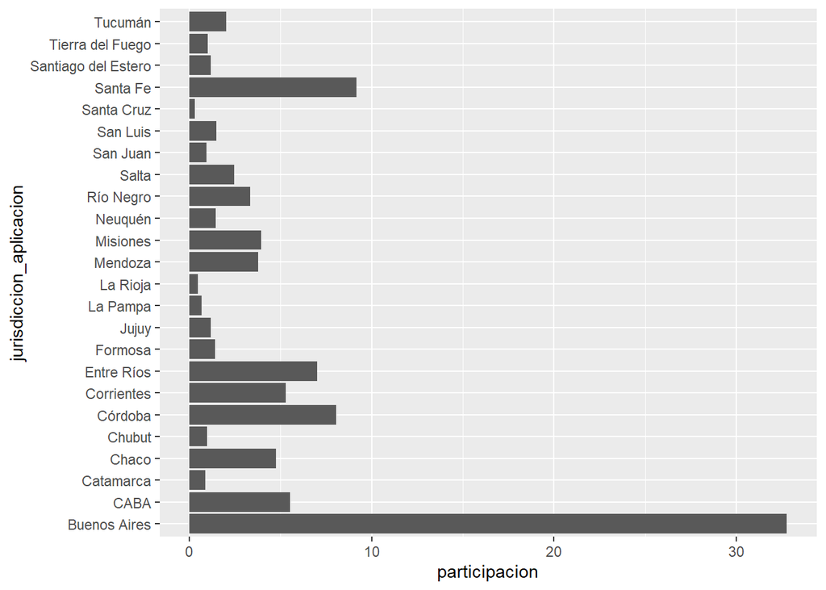

```r
ls_genvar_estdesc$jurisdiccion_aplicacion %>%
  ggplot(mapping = aes(participacion, jurisdiccion_aplicacion)) +
  geom_col()
```

```r
ggsave(paste0("png/grafico_estandar_","jurisdiccion_aplicacion", "_","total_dosis", ".png"))
```

### 1.5.6 Variables `max(fecha_aplicacion)` y `orden_dosis`

```r
varlist <- c("orden_dosis", "fecha_aplicacion")
for (esta_variable in varlist) {
  desctabla <- data_per %>% group_by(.data[[esta_variable]]) %>% summarise(n = n()) %>% mutate(prop = n / sum(n)*100)
  print(desctabla)

# almacenar en lista
ls_genvar_estdesc[[esta_variable]] <- desctabla

mas_abs <- desctabla %>%
  filter(prop == max(prop)) %>%
  select(.data[[esta_variable]])

textabla <- data.frame(abs = mas_abs)

# almacenar en lista
ls_genvar_texto[[esta_variable]] <- textabla

}
```

```
## # A tibble: 7 × 3
##   orden_dosis     n   prop
##         <dbl> <int>  <dbl>
## 1           1   864  9.81
## 2           2  1321 15.0
## 3           3  4226 48.0
## 4           4  2285 26.0
## 5           5    50  0.568
## 6           6    42  0.477
## 7           7    17  0.193
## # A tibble: 554 × 3
##    fecha_aplicacion     n   prop
##    <date>           <int>  <dbl>
##  1 2021-03-17           1 0.0114
##  2 2021-05-11           1 0.0114
##  3 2021-05-12           1 0.0114
##  4 2021-05-17           1 0.0114
##  5 2021-05-18           1 0.0114
##  6 2021-06-03           1 0.0114
##  7 2021-06-07           1 0.0114
##  8 2021-06-18           1 0.0114
##  9 2021-07-02           1 0.0114
## 10 2021-07-07           1 0.0114
## # ℹ 544 more rows
```

```r
rm("desctabla", "textabla")
```

Se observan las frecuencias de las veces que las personas fueron vacunadas segun cantidad de dosis, y en la otra tabla se obtiene la cantidad de dosis aplicadas por fecha, para las últimas aplicaciones dadas a cada persona.

La cantidad de dosis final mas observada es de 3 dosis. La fecha en que hubo mas aplicaciones de personas que no volvieron a aplicarse mas adelante nuevas dosis es

```r
ls_genvar_texto[["fecha_aplicacion"]][1,1]
```

```
## [1] "2022-01-07"
```

```r
ls_genvar_texto[["fecha_aplicacion"]]
```

```
##   fecha_aplicacion
## 1       2022-01-07
```

```r
ls_genvar_texto[["orden_dosis"]][1,1]
```

```
## [1] 3
```

```r
ls_genvar_texto[["orden_dosis"]]
```

```
##   orden_dosis
## 1           3
```

```r
rm(mas_abs, mas_rel)
```

# 2 Análisis mas detallados

## 2.1 Análisis dinámicos de los datos

En esta sección se presentan análisis dinámicos de la evolución de los datos y estadísticas en un intervalo temporal.

- Aplicaciones diarias para todo el territorio
- Días populares para vacunarse
- Días de descanso entre dosis (tiempo promedio)

### 2.1.1 Aplicaciones diarias para todo el territorio

Cantidad de dosis que se aplicaron cada día.

```r
# Obtengo data frame con aplicaciones por fecha y extiendo con el paquete lubridate.

## tabla de aplicaciones diarias:
aplicaciones_diarias <- data_reg %>%
  group_by(fecha_aplicacion) %>%
  summarise(dosis = n()) %>%
  arrange(fecha_aplicacion)

## variables tiempo con lubridate - anio mes semana dia y combinaciones. Adicionalmente para semana se especifica el formato para que no se elimine el cero delante. El cero delante ya lo deja por default para el mes.
aplicaciones_diarias <- aplicaciones_diarias %>%
  mutate(anio = year(fecha_aplicacion),
         mes = month(fecha_aplicacion),
         semana = sprintf("%02d", week(fecha_aplicacion)),
         dia = wday(fecha_aplicacion, label = TRUE, abbr = FALSE),
         anio_mes = format(fecha_aplicacion, "%Y-%m"),
         anio_semana = paste0(anio,"-",semana),
         anio_dia = paste0(anio,"-",dia))

#Ya tengo una tabla de nombre `r aplicaciones_diarias` que me permite utilizar diferentes enfoques para analizar el fenomeno temporal de la vacunacion. Voy a realizar sumas para cada unidad de tiempo y almacenar los resultados en una lista.
```

```r
# Armo una lista con agrupaciones por cantidad de aplicaciones por espacio temporal
ls_t_sumdosis = list()

sumdosis_varlist <- names(aplicaciones_diarias)[-c(1,2)]

for (unidad_tiempo in sumdosis_varlist){

ls_t_sumdosis[[unidad_tiempo]] <- aplicaciones_diarias %>%
  group_by_at(vars(one_of({{unidad_tiempo}}))) %>%
  select(dosis, {{unidad_tiempo}}) %>%
  summarise(suma_dosis = sum(dosis)) %>%
  mutate(part_dosis = suma_dosis / sum(suma_dosis) * 100) %>%
  arrange({{unidad_tiempo}})
}

#ls_t_sumdosis[["anio"]]
```